# Starbucks data: Preliminary Results

Thea Knowles

2018-03-06

This is a summary report of the Starbucks drink menu data. This text will appear in the main output.

Whenever we want to use r code, we embed it in chunks.

- Chunks can be inserted by typing alt + command + i
- Anything within a chunk will be treated like R code.
- In chunks, you can either call variables that you assigned from within your helper script, or you can create new variables to include here.

### Research question:

- In Starbucks beverages, what is the relationship between the amount of sugars and calories?

### Means

- This is an example where we call in a variable we already created (calsugs, which is a data.frame)
- Note: what does `echo = FALSE` mean?

```
## # A tibble: 9 x 3
##   Beverage_category                  cals   sug
##   <fct>                             <dbl> <dbl>
## 1 Classic Espresso Drinks          145     17.6
## 2 Coffee                             4.25   0
## 3 Frappuccino Blended Coffee       277     57.1
## 4 Frappuccino BlendedCreme         233     48.5
## 5 Frappuccino Light Blended Coffee 162     32.4
## 6 Shaken Iced Beverages            114     26.0
## 7 Signature Espresso Drinks        250     38.6
## 8 Smoothies                        282     36.8
## 9 Tazo Tea Drinks                  177     30.3
```

#### Better looking means

- Be careful not to have two chunks with identical names!

| Beverage_category | cals | sug |
| --- | --- | --- |
| Classic Espresso Drinks | 144.9107 | 17.57143 |
| Coffee | 4.2500 | 0.00000 |
| Frappuccino Blended Coffee | 276.9444 | 57.08333 |
| Frappuccino BlendedCreme | 233.0769 | 48.46154 |
| Frappuccino Light Blended Coffee | 162.5000 | 32.41667 |
| Shaken Iced Beverages | 114.4444 | 26.00000 |
| Signature Espresso Drinks | 250.0000 | 38.60000 |
| Smoothies | 282.2222 | 36.77778 |
| Tazo Tea Drinks | 177.3077 | 30.30769 |

### A preliminary plot!

- You can also leave a chunk unnamed and without any parameters specified
- This is a plot that we made in helper.R

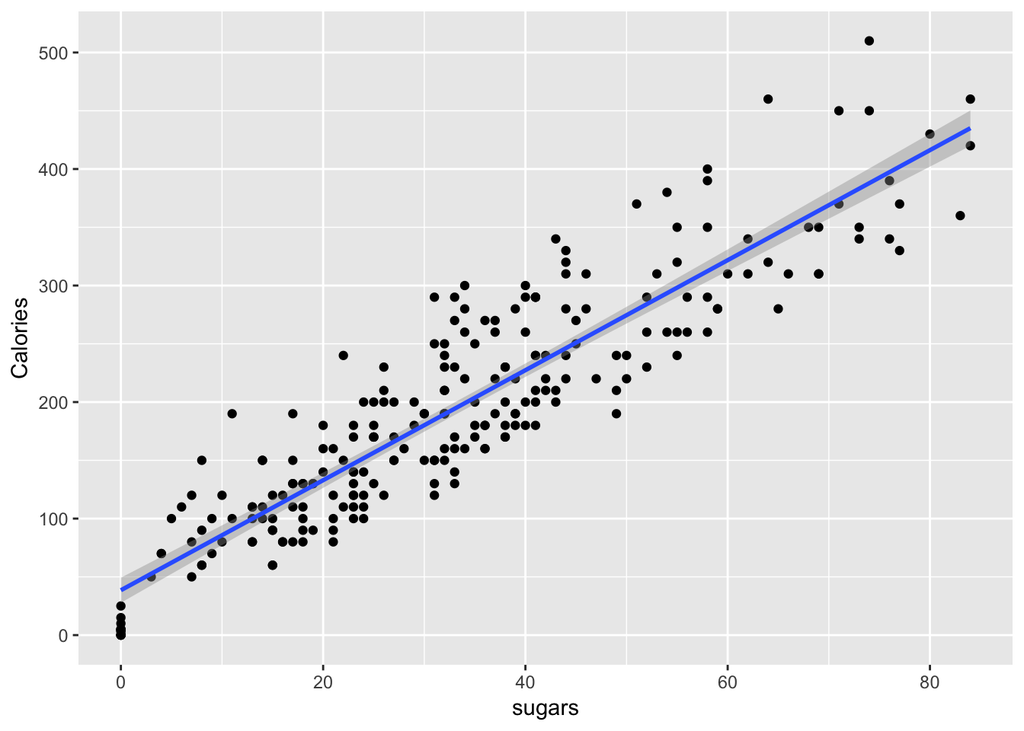

```r
calsugs_plot
```

### Another plot!

- Here we call in the same plot, but add some more details

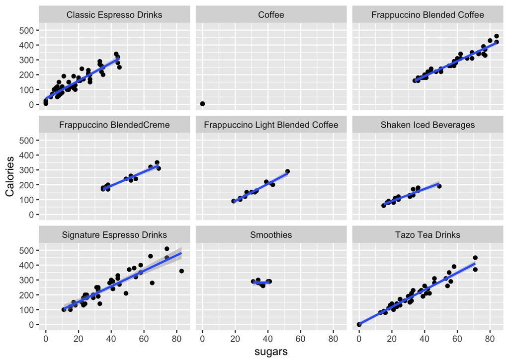

```r
calsugs_plot+
     facet_wrap(~Beverage_category)
```

### OMG ANOTHER plot!

- Here we are making a plot from scratch
  - i.e., we’re not calling a plot that has already been assigned to a variable in helper.R
- We don’t need to assign it to a variable name (<-); we can just include the code for the plot

**Calories by beverage type:**

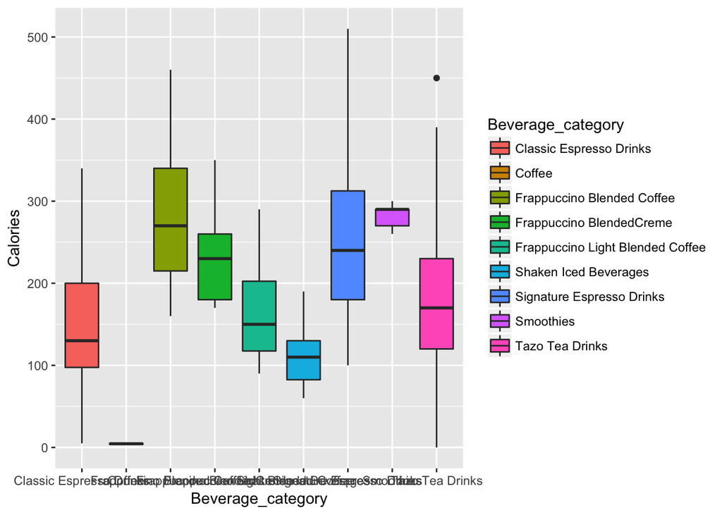

```r
ggplot(data=starbucks, aes(x=Beverage_category, y=Calories, fill=Beverage_category))+
     geom_boxplot()
```

## Exercise 3: Knit!

- Press Knit button at top of RStudio editor
- Output will default to whatever is first specified in the YAML
  - In this case: HTML
- You can also specify other types of output and select which one you would like to knit

## Exercise 4: Include a new plot!

- Insert a chunk and make a new plot
- Use the same syntax that we used to make the “Calories by beverage type” but plot “Sugars by beverage type” instead

*Insert new chunk here!*

## Exercise 5: Make a new summary .Rmd report

- See slides